# Rmarkdown and HPC training

Ido Bar

17/12/2021

# 1 HPC training

This document is written to cover the tools, information and commands to run jobs on the Griffith Gowonda HPC cluster.

## 1.1 Required Tools

You will need to have the following tools installed:

- Registered account on Gowonda (use this [link](https://conf-ers.griffith.edu.au/display/GHCD/Gowonda+HPC) to apply)
- KiTTY - see [download link](https://www.fosshub.com/KiTTY.html)
- [RStudio](https://www.rstudio.com/products/rstudio/download/#download) and [R](https://cran.r-project.org/bin/windows/base/) (with [RTools](https://cran.r-project.org/bin/windows/Rtools/rtools40.html)) for Rmarkdown

## 1.2 Login to Gowonda

We need to connect to the HPC by SSH-login to `gc-prd-hpclogin1.rcs.griffith.edu.au` (use your Griffith sNumber and password), using KiTTY (Win) or `ssh` command (Mac)

Once we’ve logged in, we can create and navigate to our working directory. The `home` folder has ~100GB capacity, while the `scratch` folder is used for short-term storage and processing of raw files, with 1TB storage.

### 1.2.1 Basic folder navigation

List files and directories

```bash
# list files and directories
ls
#long listing
ls -lh
```

Create a new folder inside `scratch` to practice:

```bash
# create a new directory
mkdir ~/scratch/sandbox
# enter the newly created folder
cd ~/scratch/sandbox
```

```bash
# bypass proxy
source ~/s3proxy.sh
# download the shell tutorial data
wget https://idobar.github.io/shell-novice/data/shell-lesson-data.zip
# unzip the files from the archive
unzip shell-lesson-data.zip
# enter the data folder
cd shell-lesson-data
```

## 1.3 Version control with Git

We can use `git` for version control and to keep track of our changes. See the following [tutorial](https://towardsdatascience.com/learn-basic-git-commands-for-your-data-science-works-2a75396d530d) and the lifecyle overview below.

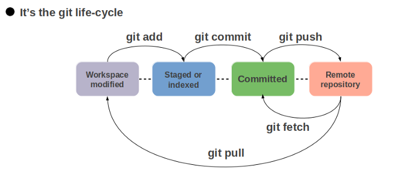

### 1.3.1 Tips and Resources

- `~` stands for your home folder (usually `/export/home/sNumber`)
- A gallery of Rmarkdown syntax highlighting styles can be found at this [blog post](https://www.garrickadenbuie.com/blog/pandoc-syntax-highlighting-examples/)